# Crane Survival Analysis

bills

2020-01-02

Load libraries

```r
library(KMsurv)
library(survival)
library(gtools)
library(Epi)
library(coda)
library(splines)
library(arm)
library(boot)
library(dplyr)
```

Read in data

```r
colt.dat<-read.csv("data_product/fates_table_corr.csv")
```

```r
colt.dat %>% filter(age_at_fate_days <= Cap.age.days)
```

```
##  [1] colt_ID
##  [2] place_name
##  [3] nest_ID
##  [4] alpha_numeric.in_parentheses_if_removed.
##  [5] sex
##  [6] age_capture.weeks.
##  [7] Cap.age.days
##  [8] Cap.yr
##  [9] Cap.month
## [10] Cap.day
## [11] capture.date
## [12] fate_date
## [13] age_at_fate_days
## [14] cond.age
## [15] censor
## [16] cause_death
## [17] mass_at_first_capture.kg.
## [18] lastka.yr
## [19] lastka.mo
## [20] lastka.day
## [21] lastdateknownalive
## [22] firstkd.yr
## [23] firstkd.mo
## [24] firstkd.day
## [25] firstdateknowndead
## [26] num_recaps.not_counting_initial_capture.
## [27] comments
## <0 rows> (or 0-length row.names)
```

Change the age_at_fate_days for these individuals so that they die mid-way through the day

```r
colt.dat$age_at_fate_days<-with(colt.dat, ifelse(age_at_fate_days <= Cap.age.days,
                                  age_at_fate_days + 0.5, age_at_fate_days))
```

## GLM survival model

### First, create daily records using the splitLexis function

```r
Colt.Lexis<-read.csv("raw_data/fates_table.csv", header=TRUE)
spl.dat<-Lexis(entry=list(age=Cap.age.days),exit=list(age=age_at_fate_days),exit.status = censor, data=Colt.Lexis)
```

```
## NOTE: entry.status has been set to 0 for all.
```

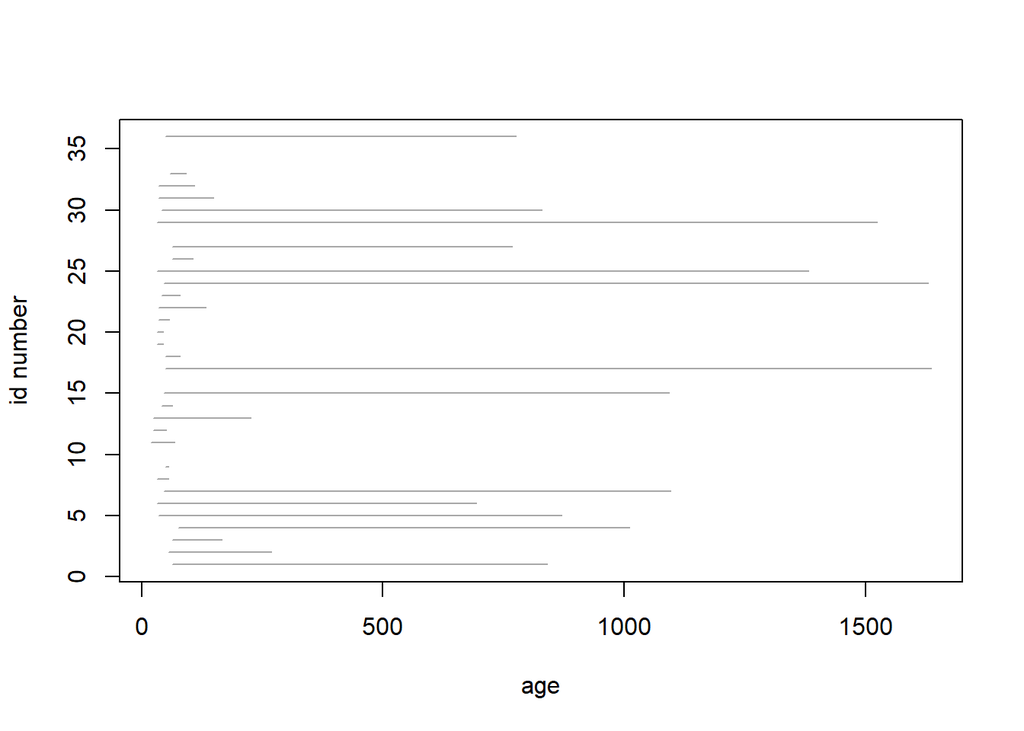

```r
plot(spl.dat)
```

```r
age.days<-seq(0,365,1)
dayobs<-splitLexis(spl.dat,breaks=age.days,time.scale="age")
dayobs$Fail<-factor(dayobs$lex.Xst)
write.csv(dayobs,file = "data_product/dayobs.csv",row.names=TRUE)
options(na.action = "na.fail")
```

### Fit models.

Note, using more htan 1 df results in warnings that the models result in fitted probabilities with 0 or 1, indicative of problems with complete separation. So, only use age as linear effect.

```r
m1.age <- glm(Fail ~ age, family = binomial(link=cloglog), data=dayobs)
```

Estimate the probability survive each day, given alive at start of the day. Start predicting at 2.7 weeks (or, min left truncation time)

```r
age<-seq(round(7*2.7), 365, 1)
pred.m.age<-1 - predict(m1.age, type = "resp",data.frame(age=age))
St.m.age <- c(1, cumprod(pred.m.age))
age2<-c(18, age) # to allow plot of survival to age 19, given alive on day 18
```

### Use a bootstrap to calculate 95% CIs

Set up information to hold the bootstrap results

```r
nsims = 500 # number of bootstraps
dayobs$Fail<-factor(dayobs$lex.Xst)
```

Store results in Shat (for survival curve) and hhat for hazard curve

```r
Shat <- matrix(NA, nrow = 348, ncol = nsims)
hhat <- matrix(NA, nrow = 347, ncol = nsims)
uid <- unique(dayobs$colt_ID)
nID <- length(uid)
for(ii in 1:nsims){
  bootIDs <- data.frame(colt_ID = sample(x = uid, size = nID, replace = TRUE))
  bootDat <- merge(bootIDs, dayobs)
  dailyS <- glm(Fail ~ age, family = binomial(link=cloglog), data=bootDat)
  dailySP <- 1 - predict(dailyS, type = "resp",data.frame(age = seq(round(7*2.7), 365, 1)))
  cum.boot <- c(1, cumprod(dailySP))
  Shat[,ii]<-cum.boot
  hhat[,ii]<-dailySP
}
```

Calculate confidence intervals for Shat (CIs) and hhat (m.CIs)

```r
CIs<-apply(as.matrix(Shat), 1, function(x){quantile(x,probs=c(0.025,0.975))})
m.CIs<-apply(as.matrix(hhat), 1, function(x){quantile(x,probs=c(0.025,0.975))})
```

## KM survival

Make sure all records are complete for entry and exit dates & censor indicator

```r
colt.dat %>% select("Cap.age.days", "age_at_fate_days", "censor") %>% complete.cases
```

```
##  [1]  TRUE  TRUE  TRUE  TRUE  TRUE  TRUE  TRUE  TRUE  TRUE  TRUE  TRUE  TRUE
## [13]  TRUE  TRUE  TRUE  TRUE  TRUE  TRUE  TRUE  TRUE  TRUE  TRUE  TRUE  TRUE
## [25]  TRUE  TRUE  TRUE  TRUE  TRUE  TRUE  TRUE  TRUE  TRUE  TRUE FALSE  TRUE
```

Inspect the one obs with incomplete data

```r
ind<-colt.dat %>% select("Cap.age.days", "age_at_fate_days", "censor") %>%
      complete.cases
colt.dat[ind==FALSE,]
```

```
##    colt_ID    place_name nest_ID alpha_numeric.in_parentheses_if_removed. sex
## 35 2015-31 Nora_Township      29                                       7E
##    age_capture.weeks. Cap.age.days Cap.yr Cap.month Cap.day capture.date
## 35                 NA           NA   2015         7      24    7/24/2015
##    fate_date age_at_fate_days cond.age censor cause_death
## 35        NA               NA   980.75      0
##    mass_at_first_capture.kg. lastka.yr lastka.mo lastka.day lastdateknownalive
## 35                        NA      2018        12         10         12/10/2018
##    firstkd.yr firstkd.mo firstkd.day firstdateknowndead
## 35         NA         NA          NA
##    num_recaps.not_counting_initial_capture.
## 35                                        0
##                                                                                                                   comments
## 35 colt was nearly fledged. Checked on 2 weeks later and had fledged. Age likely >10 weeks, >3kgs (very likely over 9 wks)
```

Drop this obs when fitting model

```r
colt <- survfit(Surv(Cap.age.days, age_at_fate_days, censor) ~ 1, data=colt.dat[ind,])
(kmfit<-summary(colt))
```

```
## Call: survfit(formula = Surv(Cap.age.days, age_at_fate_days, censor) ~
##     1, data = colt.dat[ind, ])
##
##   time n.risk n.event censored survival std.err lower 95% CI upper 95% CI
##   37.5     17       1        1    0.941  0.0571        0.836        1.000
##   44.5     19       1        1    0.892  0.0724        0.760        1.000
##   46.0     20       1        0    0.847  0.0814        0.702        1.000
##   50.0     23       1        0    0.810  0.0858        0.658        0.997
##   55.5     21       1        1    0.772  0.0900        0.614        0.970
##   56.0     20       1        0    0.733  0.0934        0.571        0.941
##   63.0     20       1        1    0.696  0.0956        0.532        0.911
##   68.2     23       1        0    0.666  0.0961        0.502        0.884
##  106.0     20       1        3    0.633  0.0969        0.469        0.854
```

Create data set for plotting starting at 2.7 weeks = 19 days

```r
kmdat<-data.frame(time=c(19, kmfit$time), survival=c(1, kmfit$surv),
                  lowCI=c(1,kmfit$lower), upCI=c(1, kmfit$upper))
```

Plot in a single 2-panel fig.

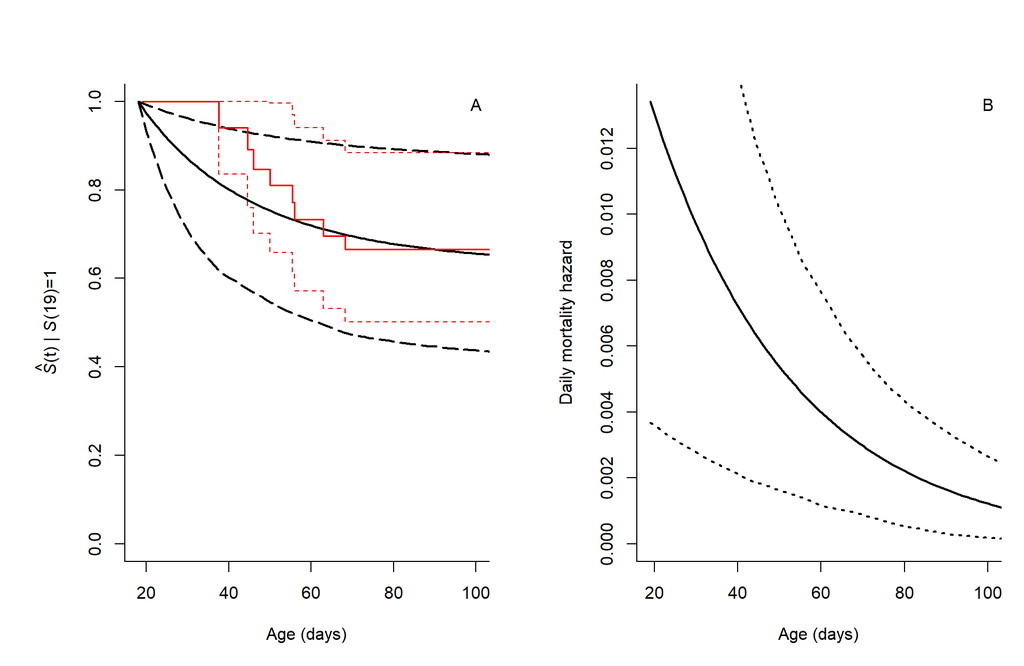

```r
par(mfrow=c(1,2), bty="L")
par(mar=c(5,6,4,1)+0.1)
plot(age2, St.m.age, type="l",lwd=2,ylim=c(0,1),xlab="Age (days)",
     ylab=expression(paste(hat(italic(S)),"(t) | ",italic(S),"(19)=1")), xlim=c(18, 100)) #italics S-hat
lines(age2, CIs[1,], lty=5,lwd=2)
lines(age2, CIs[2,], lty=5,lwd=2)
lines(kmdat$time, kmdat$survival, col="red", type="s", lwd=1.5)
lines(kmdat$time, kmdat$lowCI, col="red", type="s", lty=2)
lines(kmdat$time, kmdat$upCI, col="red", type="s", lty=2)
legend("topright", legend=c("A"),bty="n")
plot(age, 1-(pred.m.age),type="l",
     lwd=2,ylab="Daily mortality hazard", xlab="Age (days)",
      xlim=c(19, 100))
lines(age, 1-m.CIs[1,], lty=3, lwd=2)
lines(age, 1-m.CIs[2,], lty=3, lwd=2)
legend("topright", legend=c("B"),bty="n")
```